# Web Scraping using Premier League Data 21/22

Using the library BeautifulSoup, I will be scraping and parsing through HTML data to create several dataframes and graphs to analyze Premier League data from the 2021/2022 season. Below I have imported all the libraries I will be utilizing to help with my analysis.

```python
from bs4 import BeautifulSoup
import requests
import pandas as pd
import numpy as np
import re
import matplotlib.pyplot as plt
import seaborn as sns
import plotly.express as px
from scipy.stats import pearsonr
```

## Webscraping using FBref

FBref.com is a free website that provides full coverage data and stats of football leagues all around the world. I will specifically be using the Premier League stats of the 21/22 season in order to retrieve relevant data such as the number of wins, losses, goals scored, goals expected, etc to summarize and explain what happened during that season.

Using BeautifulSoup, we will extract our data table using the HTML parser.

```python
#Take site and structure html
URL = 'https://fbref.com/en/comps/9/2021-2022/2021-2022-Premier-League-Stats'
page = requests.get(URL)

soup = BeautifulSoup(page.content, "html.parser")
results = soup.find('table', id="results2021-202291_overall")

#Find all column names in table of website
headers = []

for i in results.find_all('th'):
 title = i.text
 headers.append(title)
```

## Creating a Dataframe Table for the Overall Season 21/22 Results

Below, I am simply extracting the table from the FBref website and storing the data as a Pandas dataframe. It is displayed below. I also changed the *object* data type to be an integer or float data type to allow for calculations further into the analysis.

```python
#Create a dataframe using the headers as columns
mydata = pd.DataFrame(columns = headers[1:19])
mydata

#Create a for loop to fill all the data into its respective columns
for j in results.find_all('tr')[1:21]:
 row_data = j.find_all('td')
 row = [i.text for i in row_data]
 length = len(mydata)
 #print(length)
 mydata.loc[length] = row

#Shift dataframe index to start at 1
mydata.index = mydata.index + 1
mydata

#Change variables into respective data types:
mydata['Pts'] = mydata['Pts'].astype(int)
mydata['Pts'].dtypes

#Convert xG to float type
mydata['xG'] = mydata['xG'].astype(float)
mydata['xG'].dtypes

#Convert Goals For to int type
mydata['GF'] = mydata['GF'].astype(int)
mydata['GF'].dtypes

#Convert Goals Against to int type
mydata['GA'] = mydata['GA'].astype(int)
mydata['GA'].dtypes

#Convert Goals Diff to int type
mydata['GD'] = mydata['GD'].astype(int)
mydata['GD'].dtypes

#Convert W to int type
mydata['W'] = mydata['W'].astype(int)
mydata['W'].dtypes

#Convert D to int type
mydata['D'] = mydata['D'].astype(int)
mydata['D'].dtypes

#Convert L to int type
mydata['L'] = mydata['L'].astype(int)
mydata['L'].dtypes


mydata['Attendance'] = mydata['Attendance'].str.replace(',', '').astype(int)
mydata['Attendance'].dtypes

mydata
```

|  | Squad | MP | W | D | L | GF | GA | GD | Pts | Pts/MP | xG | xGA | xGD | xGD/90 | Attendance | Top Team Scorer | Goalkeeper | Notes |
| --- | --- | --- | --- | --- | --- | --- | --- | --- | --- | --- | --- | --- | --- | --- | --- | --- | --- | --- |
| 1 | Manchester City | 38 | 29 | 6 | 3 | 99 | 26 | 73 | 93 | 2.45 | 88.7 | 24.6 | +64.0 | +1.68 | 52774 | Kevin De Bruyne - 15 | Ederson | → Champions League via league finish |
| 2 | Liverpool | 38 | 28 | 8 | 2 | 94 | 26 | 68 | 92 | 2.42 | 88.7 | 33.8 | +54.9 | +1.45 | 53352 | Mohamed Salah - 23 | Alisson | → Champions League via league finish |
| 3 | Chelsea | 38 | 21 | 11 | 6 | 76 | 33 | 43 | 74 | 1.95 | 63.4 | 33.2 | +30.1 | +0.79 | 36443 | Mason Mount - 11 | Edouard Mendy | → Champions League via league finish |
| 4 | Tottenham | 38 | 22 | 5 | 11 | 69 | 40 | 29 | 71 | 1.87 | 61.2 | 39.3 | +21.9 | +0.58 | 56523 | Son Heung-min - 23 | Hugo Lloris | → Champions League via league finish |
| 5 | Arsenal | 38 | 22 | 3 | 13 | 61 | 48 | 13 | 69 | 1.82 | 60.5 | 45.7 | +14.9 | +0.39 | 59665 | Bukayo Saka - 11 | Aaron Ramsdale | → Europa League via league finish |
| 6 | Manchester Utd | 38 | 16 | 10 | 12 | 57 | 57 | 0 | 58 | 1.53 | 55.8 | 53.0 | +2.8 | +0.07 | 73150 | Cristiano Ronaldo - 18 | David de Gea | → Europa League via league finish |
| 7 | West Ham | 38 | 16 | 8 | 14 | 60 | 51 | 9 | 56 | 1.47 | 51.4 | 53.5 | -2.1 | -0.06 | 58370 | Jarrod Bowen - 12 | Łukasz Fabiański | → Europa Conference League via league finish |
| 8 | Leicester City | 38 | 14 | 10 | 14 | 62 | 59 | 3 | 52 | 1.37 | 47.8 | 59.3 | -11.5 | -0.30 | 32493 | Jamie Vardy - 15 | Kasper Schmeichel |  |
| 9 | Brighton | 38 | 12 | 15 | 11 | 42 | 44 | -2 | 51 | 1.34 | 46.2 | 42.9 | +3.3 | +0.09 | 30966 | Leandro Trossard, Neal Maupay - 8 | Robert Sánchez |  |
| 10 | Wolves | 38 | 15 | 6 | 17 | 38 | 43 | -5 | 51 | 1.34 | 37.5 | 56.9 | -19.4 | -0.51 | 30841 | Raúl Jiménez - 6 | José Sá |  |
| 11 | Newcastle Utd | 38 | 13 | 10 | 15 | 44 | 62 | -18 | 49 | 1.29 | 38.1 | 57.1 | -19.0 | -0.50 | 51487 | Callum Wilson - 8 | Martin Dúbravka |  |
| 12 | Crystal Palace | 38 | 11 | 15 | 12 | 50 | 46 | 4 | 48 | 1.26 | 46.4 | 40.7 | +5.7 | +0.15 | 24588 | Wilfried Zaha - 14 | Vicente Guaita |  |
| 13 | Brentford | 38 | 13 | 7 | 18 | 48 | 56 | -8 | 46 | 1.21 | 45.8 | 48.5 | -2.7 | -0.07 | 16918 | Ivan Toney - 12 | David Raya |  |
| 14 | Aston Villa | 38 | 13 | 6 | 19 | 52 | 54 | -2 | 45 | 1.18 | 44.0 | 49.0 | -4.9 | -0.13 | 41681 | Ollie Watkins - 11 | Emiliano Martínez |  |
| 15 | Southampton | 38 | 9 | 13 | 16 | 43 | 67 | -24 | 40 | 1.05 | 44.8 | 60.0 | -15.2 | -0.40 | 30134 | James Ward-Prowse - 10 | Fraser Forster |  |
| 16 | Everton | 38 | 11 | 6 | 21 | 43 | 66 | -23 | 39 | 1.03 | 41.2 | 55.4 | -14.2 | -0.37 | 38446 | Richarlison - 10 | Jordan Pickford |  |
| 17 | Leeds United | 38 | 9 | 11 | 18 | 42 | 79 | -37 | 38 | 1.00 | 44.4 | 67.8 | -23.5 | -0.62 | 36308 | Raphinha - 11 | Illan Meslier |  |
| 18 | Burnley | 38 | 7 | 14 | 17 | 34 | 53 | -19 | 35 | 0.92 | 39.7 | 57.1 | -17.4 | -0.46 | 19278 | Maxwel Cornet - 9 | Nick Pope | Relegated |
| 19 | Watford | 38 | 6 | 5 | 27 | 34 | 77 | -43 | 23 | 0.61 | 40.0 | 64.5 | -24.5 | -0.64 | 20614 | Emmanuel Dennis - 10 | Ben Foster | Relegated |
| 20 | Norwich City | 38 | 5 | 7 | 26 | 23 | 84 | -61 | 22 | 0.58 | 32.3 | 75.5 | -43.2 | -1.14 | 26836 | Teemu Pukki - 11 | Tim Krul | Relegated |

## Plotting Data using Matplotlib

### Points

**Q: Who won the EPL and how many points did they finish with?**

The plot below displays the points recieved over the 21/22 Premier League season.

- Manchester City won the league by finishing 1 point ahead of Liverpool.
- Burnley, Watford and Norwich City, who finished with 35, 23, and 22 points respecitvely were relegated to the second division.

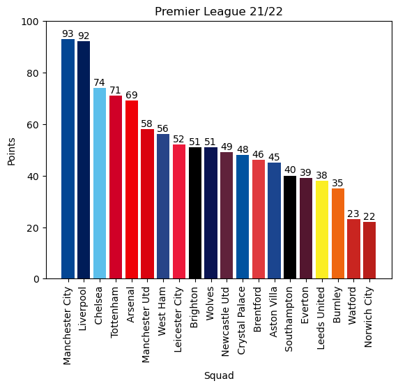

```python
#Create list of colors for each team
teamColors = ['#034694','#001C58','#5CBFEB','#D00027',
              '#EF0107','#DA020E','#274488','#ED1A3B',
               '#000000','#091453','#60223B','#0053A0',
               '#E03A3E','#1B458F','#000000','#53162f',
               '#FBEE23','#EF6610','#C92520','#BA1F1A']

#Plot points for 21/22 season for each team respectively
plt.bar(x = mydata["Squad"], height = mydata["Pts"], color = teamColors)
plt.xticks(rotation=90)
plt.title("Premier League 21/22")
plt.xlabel("Squad")
plt.ylabel("Points")
plt.ylim(0, 100)

#Display text above each bar representing actual points received in season
pts_list = mydata['Pts'].tolist()
pts_list

for i in range(1, 21):
    plt.text(i - 1.4, pts_list[i-1] + 1, pts_list[i-1], ha = "left")
```

### Wins, Draws, and Losses

**Q: Which team had the most wins in the season? Losses? Draws?**

The bar plot below shows the wins, draws, and losses out of 38 total completed matches. It is evident that the winners of the league, Manchester City ended the season with the most wins (29 matches). Brighton and Crystal Palace tied with the most draws in the season (15 matches). Watford ended the season with the most losses (27 matches).

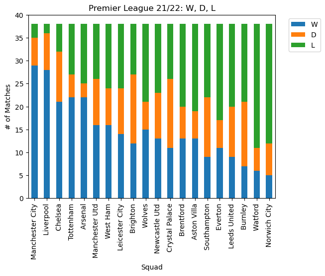

```python
status = ['W', 'D', 'L']
#mydata.plot(x = 'Squad', y = status, kind = 'bar')
mydata.plot.bar(x = 'Squad', y = status, stacked = True)
plt.title("Premier League 21/22: W, D, L")
plt.ylabel("# of Matches")
plt.ylim([0, 40])
plt.legend(bbox_to_anchor=(1.04, 1), loc="upper left")
plt.show()
```

### Goals in the Season

**Q: Who scored the most goals during the season? Least goals? Who recieved the most goals? Least goals?**

A total of 1,071 goals were scored in the 21/22 season. Manchester City scored the highest amount of goals, with 99. On the other hand, Norwich City scored just 23 goals. In terms of goals received, Man City and Liverpool tied with the lowest, having 26 goals scored against them.

Not only did Norwich City score the least amount of goals, but they also recieved the most, having a total of 84 goals against them.

```python
totalGoals = mydata["GF"].sum()
totalGoals
```

```
1071
```

Manchester City scored 9.2% of the total goals scored in the 21/22 season.

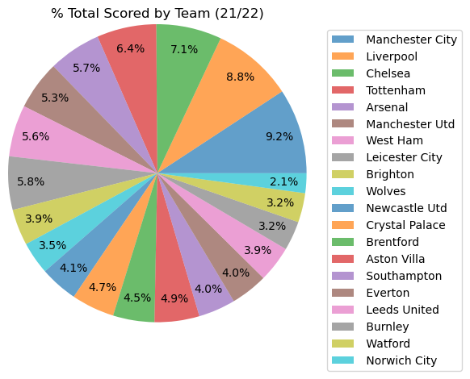

```python
y = mydata["GF"]
mylabels = mydata["Squad"]
plt.pie(y, autopct='%1.1f%%', radius = 1.25, pctdistance = 0.85, wedgeprops = {"alpha": 0.7})
plt.legend(labels = mylabels, bbox_to_anchor=(1.05, 1.0), loc='upper left')
plt.title('% Total Scored by Team (21/22)')
plt.show()
```

#### Goals Scored vs Goals Recieved

In the bar plot below, it is apparent that Manchester City scored the most goals during the season while Norwich City had the most goals scored against their team.

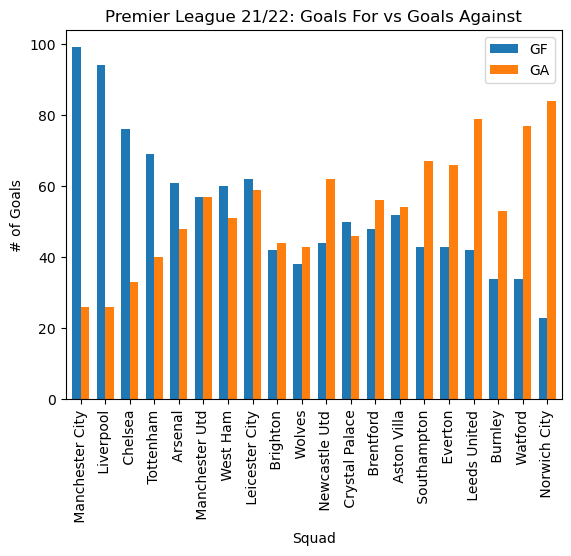

```python
#Variable containing list of both goals scored + goals conceded for each team
gf_ga = ['GF', 'GA']
mydata.plot(x = 'Squad', y = gf_ga, kind = 'bar', width = 0.7)
plt.title("Premier League 21/22: Goals For vs Goals Against")
plt.ylabel("# of Goals")
plt.show()
```

#### Goal Difference

Goal difference is calculated as the following: GD = GF - GA, which means we subtract the goals conceded from the goals scored. From the plot below, we can see Norwich had the worst goal difference while Man City had the best.

A negative value indicates that the team had more goals against them. A positive value indicates that a team scored more goals than recieved. We can see that teams like Manchester United had a goal difference of 0 which indicates they scored the same number of goal that they recieved.

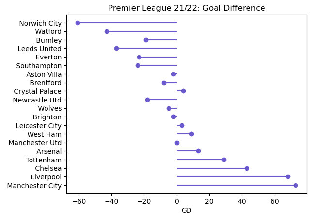

```python
plt.hlines(y = mydata["Squad"], xmin = 0, xmax = mydata["GD"], color = 'slateblue')
plt.plot(mydata["GD"], mydata["Squad"], 'o', color='slateblue')
plt.title("Premier League 21/22: Goal Difference")
plt.xlabel('GD')
plt.show()
```

#### Expected Goals in the Season vs Actual Goals

Source: https://footballxg.com/

Expected goals (xG) calculates how many goals a team should have scored based on the quality of the chances created. It is a more accurate and fairer assessment than shots on targets. By comparing xG scores vs the actual goals scored, we can determine the teams scoring performance. For example, if the xG vs Actual value is **negative**, then the team scored **less** then they were expected to. If the value was **positive**, then the team overacheived by scoring **more** than what was expected.

**Q: How does expected goals (xG) compare to the actual goals scored during the season?**

Below in the dataframe, the xG was subtracted from the actual scored goals to give us the difference between actual vs expected.

- In the 21/22 season, Leicester City scored about 14 more goals than was expected. On the other hand, Norwich scored around 9 less goals than they were expected to. In simple terms, it can be stated that Leicester overachieved in goal scoring since they scored around 14 (~14.2) goals than was predicted during the season.

```python
squads = mydata['Squad'].tolist()
xg_list = mydata['xG'].tolist()

squads1 = mydata['Squad'].tolist()
actualG_list = mydata['GF'].tolist()


diffGF_xG = np.subtract(actualG_list,xg_list)

outcome = pd.DataFrame(diffGF_xG, index = squads, columns = ['xG vs Actual'])
outcome
```

|  | xG vs Actual |
| --- | --- |
| Manchester City | 10.3 |
| Liverpool | 5.3 |
| Chelsea | 12.6 |
| Tottenham | 7.8 |
| Arsenal | 0.5 |
| Manchester Utd | 1.2 |
| West Ham | 8.6 |
| Leicester City | 14.2 |
| Brighton | -4.2 |
| Wolves | 0.5 |
| Newcastle Utd | 5.9 |
| Crystal Palace | 3.6 |
| Brentford | 2.2 |
| Aston Villa | 8.0 |
| Southampton | -1.8 |
| Everton | 1.8 |
| Leeds United | -2.4 |
| Burnley | -5.7 |
| Watford | -6.0 |
| Norwich City | -9.3 |

As stated above, Leicester City overachieved in goal-scoring performance and this can be seen in the graph below. Norwich's underachieving performance can also be seen in the graph. Arsenal and Wolves were the closest in terms of actually scoring like they were expected to.

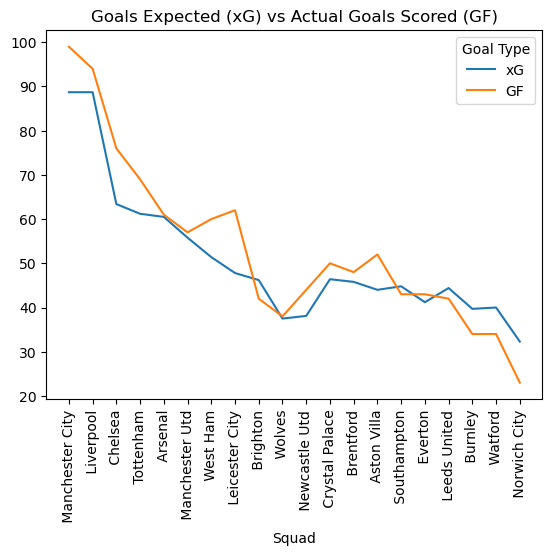

```python
plt.plot(squads, xg_list, label = "xG")
plt.gca().invert_yaxis()

plt.plot(squads1, actualG_list, label = "GF")
plt.gca().invert_yaxis()

plt.xticks(rotation = 90)
plt.legend(title = "Goal Type")

plt.title("Goals Expected (xG) vs Actual Goals Scored (GF)")
plt.xlabel("Squad")
plt.show()
```

#### Attendance at Home Matches vs Total Wins in Season

**Q: Did the attendance at home matches during the 21/22 season affect the number of wins?**

Although there needs to be more data to determine if there is an advantage when playing a home match or if the attendance numbers have any influence on the number of matches won, I attempted to do a correlation test using the average attendance per home match and the number of wins in the 21/22 season.

Below I used a scatter plot to display attendance vs game wins.

```python
#Scatter plot for attendance vs wins

plt = px.scatter(mydata, x = "Attendance", y = "W", color = 'Squad',
                trendline="ols", trendline_color_override = 'black', trendline_scope="overall")

plt.update_layout(
            title={
            'text' : "<b>Attendance per Game vs Wins in Season",
            'x':0.5,
            'xanchor': 'center'
        })

plt.show()
```

[interactive chart not shown]

Using the **pearsonr** function from the scipy library, I was able to find the correlation coefficent as well as the two tailed p-value to determine if there was any relationship or significance regarding both variables (attendance/wins).

- The correlation coefficent r = 0.6496
- The 2-tailed p-value = 0.0019

The correlation coefficient tells us that there is a good/moderate positive correlation between attendance and wins. The closer to 1, the strong the positive correlation is. This positive correlation can be interpreted as the following: the more people attend a home match, then the higher number of wins during the season.

The p-value also suggests that there is a statistically significant association between both variables.

```python
mydata['Attendance'].corr(mydata['W'])


r_coef = pearsonr(mydata['Attendance'], mydata['W'])[0]
p_val = pearsonr(mydata['Attendance'], mydata['W'])[1]

print("Correlation coefficent:",r_coef)
print("p-value:",p_val)
```

```
Correlation coefficent: 0.6496194853740449
p-value: 0.0019355235189621274
```

## Creating a Dataframe for 90 Minute Stats

I also wanted to analyze the season by looking at the per-90-minute statistics. These per 90 stats measure certain values over the 90 minute period of a match. Using the 2nd table called *Squad Standard Stats* from the FBref website, I created 2 distinct dataframes with the information I wanted and concatenated them.

### Concatenating 2 Dataframes

The first three columns of this data frame will contain the average number of players used throughout the season, the average age of each team (age weighted by minutes played) and the average possession of the ball.

The remaining columns will be the per 90 minute stats such as goals/90, assists/90, etc.

Below is the code used to scape data from another table on the FBref website and looping through the parsed data to store into a new dataframe.

```python
table2 = soup.find('table', id="stats_squads_standard_for")

#Find all column names in table of website
headers2 = []

for m in table2.find_all('th'):
 title = m.text
 headers2.append(title)

standardStats = pd.DataFrame(columns = headers2[7:10])
#print(len(standardStats))


#Create a for loop to fill all the data into its respective columns
for m in table2.find_all('tr')[2:22] :
 row_data = m.find_all('td')[0:3]
 #print(row_data)
 row = [n.text for n in row_data]
 #print(row)
 length = len(standardStats)
 #print(length)
 standardStats.loc[length] = row

#Shift dataframe index to start at 1
standardStats.index = standardStats.index + 1

#standardStats
```

```python
#--------Data for XG/90 etc --------------------

standardStats2 = pd.DataFrame(columns = headers2[28:38])

for m in table2.find_all('tr')[2:22] :
 row_data = m.find_all('td')[21:31]
 #print(row_data)
 row = [n.text for n in row_data]
 #print(row)
 length = len(standardStats2)
 #print(length)
 standardStats2.loc[length] = row

standardStats2.index = standardStats2.index + 1
#standardStats2
```

```python
#--------Data for yellow cards --------------------

standardStats3 = pd.DataFrame(columns = headers2[20:21])

for m in table2.find_all('tr')[2:22] :
 row_data = m.find_all('td')[13:14]
 #print(row_data)
 row = [n.text for n in row_data]
 #print(row)
 length = len(standardStats3)
 #print(length)
 standardStats3.loc[length] = row

index_labels = ['Arsenal','Aston Villa','Brentford','Brighton','Burnley','Chelsea', 'Crystal Palace',
'Everton', 'Leeds United', 'Leicester City', 'Liverpool', 'Manchester City', 'Manchester Utd',
'Newcastle Utd','Norwich City', 'Southampton', 'Tottenham', 'Watford', 'West Ham', 'Wolves']

#per90Stats = pd.DataFrame(standardStatsFinal, index = index_labels)
standardStats3.index = index_labels

#standardStats3.index = standardStats3.index + 1
#standardStats3
```

### Per 90 Minute Stats Dataframe Table:

Table Definitions:

- **G+A**: Goals and Assists
- **G-PK**: Goals - Penalty kicks made (essentially non-penalty goals)
- **XG** : Expected goals, including penalties
- **npxG**: Expected non-penalty goals

Below I have concatenated 2 dataframes with the following code:

```python
#-------------Below concat 2 dataframes------------------

per90stats = pd.concat([standardStats, standardStats2], axis = 1)
per90stats

index_labels = ['Arsenal','Aston Villa','Brentford','Brighton','Burnley','Chelsea', 'Crystal Palace',
'Everton', 'Leeds United', 'Leicester City', 'Liverpool', 'Manchester City', 'Manchester Utd',
'Newcastle Utd','Norwich City', 'Southampton', 'Tottenham', 'Watford', 'West Ham', 'Wolves']

#per90Stats = pd.DataFrame(standardStatsFinal, index = index_labels)
per90stats.index = index_labels

#convert all columns into float type
per90stats['Poss'] = per90stats['Poss'].astype(float)
per90stats['Gls'] = per90stats['Gls'].astype(float)
per90stats['Ast'] = per90stats['Ast'].astype(float)
per90stats['G+A'] = per90stats['G+A'].astype(float)
per90stats['G-PK'] = per90stats['G-PK'].astype(float)
per90stats['G+A-PK'] = per90stats['G+A-PK'].astype(float)
per90stats['xG'] = per90stats['xG'].astype(float)
per90stats['xAG'] = per90stats['xAG'].astype(float)
per90stats['xG+xAG'] = per90stats['xG+xAG'].astype(float)
per90stats['npxG'] = per90stats['npxG'].astype(float)
per90stats['npxG+xAG'] = per90stats['npxG+xAG'].astype(float)

per90stats = pd.concat([per90stats, standardStats3], axis = 1)
per90stats['CrdY'] = per90stats['CrdY'].astype(int)

per90stats['Team'] = ['ARS', 'AVL', 'BRE', 'BRI', 'BUR', 'CHE', 'CRY', 'EVE', 'LEE', 'LEI',
                        'LIV', 'MCI', 'MUN', 'NEW', 'NOR', 'SOU', 'TOT', 'WAT', 'WHU', 'WOL']

per90stats
```

|  | # Pl | Age | Poss | Gls | Ast | G+A | G-PK | G+A-PK | xG | xAG | xG+xAG | npxG | npxG+xAG | CrdY | Team |
| --- | --- | --- | --- | --- | --- | --- | --- | --- | --- | --- | --- | --- | --- | --- | --- |
| Arsenal | 27 | 24.4 | 52.8 | 1.58 | 1.08 | 2.66 | 1.45 | 2.53 | 1.59 | 1.06 | 2.65 | 1.45 | 2.51 | 67 | ARS |
| Aston Villa | 31 | 26.1 | 46.5 | 1.32 | 1.11 | 2.42 | 1.24 | 2.34 | 1.16 | 0.92 | 2.08 | 1.10 | 2.02 | 81 | AVL |
| Brentford | 29 | 25.4 | 44.8 | 1.21 | 0.87 | 2.08 | 1.05 | 1.92 | 1.21 | 0.87 | 2.07 | 1.08 | 1.95 | 65 | BRE |
| Brighton | 26 | 26.2 | 54.4 | 1.05 | 0.79 | 1.84 | 0.95 | 1.74 | 1.21 | 0.85 | 2.06 | 1.07 | 1.92 | 72 | BRI |
| Burnley | 23 | 28.5 | 40.2 | 0.84 | 0.68 | 1.53 | 0.82 | 1.50 | 1.05 | 0.82 | 1.87 | 1.00 | 1.82 | 68 | BUR |
| Chelsea | 26 | 27.4 | 61.8 | 1.97 | 1.37 | 3.34 | 1.76 | 3.13 | 1.67 | 1.18 | 2.85 | 1.49 | 2.67 | 63 | CHE |
| Crystal Palace | 24 | 27.1 | 51.1 | 1.32 | 0.82 | 2.13 | 1.16 | 1.97 | 1.22 | 0.82 | 2.04 | 1.06 | 1.87 | 69 | CRY |
| Everton | 33 | 26.7 | 40.0 | 1.11 | 0.76 | 1.87 | 0.95 | 1.71 | 1.09 | 0.75 | 1.83 | 0.94 | 1.69 | 82 | EVE |
| Leeds United | 29 | 26.1 | 52.3 | 1.11 | 0.68 | 1.79 | 0.97 | 1.66 | 1.17 | 0.82 | 1.99 | 1.06 | 1.89 | 101 | LEE |
| Leicester City | 28 | 26.5 | 52.0 | 1.63 | 1.21 | 2.84 | 1.58 | 2.79 | 1.26 | 0.90 | 2.16 | 1.22 | 2.12 | 55 | LEI |
| Liverpool | 27 | 27.7 | 62.7 | 2.47 | 1.87 | 4.34 | 2.29 | 4.16 | 2.33 | 1.67 | 4.00 | 2.18 | 3.85 | 50 | LIV |
| Manchester City | 26 | 27.0 | 67.9 | 2.53 | 1.66 | 4.18 | 2.34 | 4.00 | 2.33 | 1.72 | 4.06 | 2.14 | 3.87 | 42 | MCI |
| Manchester Utd | 29 | 27.2 | 52.7 | 1.47 | 1.21 | 2.68 | 1.39 | 2.61 | 1.47 | 1.12 | 2.59 | 1.36 | 2.48 | 77 | MUN |
| Newcastle Utd | 29 | 27.5 | 40.4 | 1.08 | 0.61 | 1.68 | 1.00 | 1.61 | 1.00 | 0.68 | 1.68 | 0.94 | 1.62 | 81 | NEW |
| Norwich City | 28 | 26.2 | 42.9 | 0.55 | 0.42 | 0.97 | 0.47 | 0.89 | 0.85 | 0.64 | 1.49 | 0.79 | 1.43 | 57 | NOR |
| Southampton | 25 | 25.7 | 47.7 | 1.08 | 0.68 | 1.76 | 0.97 | 1.66 | 1.18 | 0.85 | 2.03 | 1.10 | 1.95 | 65 | SOU |
| Tottenham | 25 | 26.5 | 51.8 | 1.66 | 1.32 | 2.97 | 1.53 | 2.84 | 1.61 | 1.24 | 2.85 | 1.51 | 2.75 | 69 | TOT |
| Watford | 30 | 28.4 | 40.7 | 0.87 | 0.68 | 1.55 | 0.84 | 1.53 | 1.05 | 0.86 | 1.91 | 1.01 | 1.87 | 63 | WAT |
| West Ham | 25 | 28.2 | 47.9 | 1.53 | 1.21 | 2.74 | 1.42 | 2.63 | 1.35 | 0.99 | 2.34 | 1.23 | 2.22 | 52 | WHU |
| Wolves | 26 | 27.3 | 49.5 | 0.92 | 0.58 | 1.50 | 0.89 | 1.47 | 0.99 | 0.69 | 1.68 | 0.97 | 1.66 | 62 | WOL |